# CA - Recommender System 2019

Norvin Chandra - E0384966

28 Oct 2019

## Data Exploration and Preparation

Get the Amazon Review Data

```
##        Id  ProductId         UserId               ProfileName
## 1: 568449 B001EO7N10 A1F6BHEYB7R6R7              James Braley
## 2: 568450 B001EO7N10 A28KG5XORO54AY          Lettie D. Carter
## 3: 568451 B003S1WTCU A3I8AFVPEE8KI5                 R. Sawyer
## 4: 568452 B004I613EE A121AA1GQV751Z           pksd ""pk_007""
## 5: 568453 B004I613EE  A3IBEVCTXKNOH Kathy A. Welch ""katwel""
## 6: 568454 B001LR2CU2 A3LGQPJCZVL9UC                  srfell17
##    HelpfulnessNumerator HelpfulnessDenominator Score       Time
## 1:                    0                      0     5 1308096000
## 2:                    0                      0     5 1299628800
## 3:                    0                      0     2 1331251200
## 4:                    2                      2     5 1329782400
## 5:                    1                      1     5 1331596800
## 6:                    0                      0     5 1338422400
##                               Summary
## 1:      Very large ground spice jars.
## 2:                Will not do without
## 3:                       disappointed
## 4:           Perfect for our maltipoo
## 5: Favorite Training and reward treat
## 6:                        Great Honey
##                                                                                                                                                                                                                                                                                                          …
## 1:                                                                                                                                                                                                                                                      My only complaint is that there's so much of it, …
## 2:                                                                                                                                                                                                                                  Great for sesame chicken..this is a good if not better than resturant…
## 3:                                                                                                                           I'm disappointed with the flavor. The chocolate notes are especially weak. Milk thickens it but the flavor still disappoints. This was worth a try but I'll never buy again.…
## 4: These stars are small, so you can give 10-15 of those in one training session.  I tried to train our dog with ""Ceaser dog treats"",  it just made our puppy hyper.  If you compare the ingredients, you will know why.  Little stars has just basic food ingredients without any preservatives and fo…
## 5:                                                                                                                                                                               These are the BEST treats for training and rewarding your dog for being good while grooming.  Lower in calories and love…
## 6:                                                                                                                                                                                                                                                                        I am very satisfied ,product is…
```

Data Structure

```
## Classes 'data.table' and 'data.frame':   568454 obs. of  10 variables:
##  $ Id                    : int  1 2 3 4 5 6 7 8 9 10 ...
##  $ ProductId             : chr  "B001E4KFG0" "B00813GRG4" "B000LQOCH0" "B000UA0QIQ" ...
##  $ UserId                : chr  "A3SGXH7AUHU8GW" "A1D87F6ZCVE5NK" "ABXLMWJIXXAIN" "A395BORC6FGVXV" ...
##  $ ProfileName           : chr  "delmartian" "dll pa" "Natalia Corres \"\"Natalia Corres\"\"" "Karl" ...
##  $ HelpfulnessNumerator  : int  1 0 1 3 0 0 0 0 1 0 ...
##  $ HelpfulnessDenominator: int  1 0 1 3 0 0 0 0 1 0 ...
##  $ Score                 : int  5 1 4 2 5 4 5 5 5 5 ...
##  $ Time                  : int  1303862400 1346976000 1219017600 1307923200 1350777600 1342051200 1340150400 1336003200 1322006400 1351209600 ...
##  $ Summary               : chr  "Good Quality Dog Food" "Not as Advertised" "\"\"Delight\"\" says it all" "Cough Medicine" ...
##  $ Text                  : chr  "I have bought several of the Vitality canned dog food products and have found them all to be of good quality. T"| __truncated__ "Product arrived labeled as Jumbo Salted Peanuts...the peanuts were actually small sized unsalted. Not sure if t"| __truncated__ "This i…
##  - attr(*, ".internal.selfref")=<externalptr>
```

```r
# Delete irrelevant character from UserId
reviews$UserId <- str_replace_all(reviews$UserId, '#oc-', '' )

# remove duplicated UsedId and ProductId
reviews <- reviews[!duplicated(reviews[,c(2,3)]),]

# Select needed columns, ProductId, Id, UserId, ProfileName, Score, Summary, Text, count, mean_score
reviews2 <- reviews[,c(1:4, 7, 9:10)]

# combine Summary and the review Text body
reviews2 <- reviews2 %>%
    mutate(combine_summary = paste(Summary, Text))
```

Check for Duplicated combine_summary and remove

```r
nrow(reviews2[duplicated(reviews2$combine_summary),])
```

```
## [1] 167327
```

```r
reviews2 <- reviews2[!duplicated(reviews2$combine_summary),]
```

```r
#head(reviews2)
```

We counted number of review for each product to find out product with low review to be filtered out to reduce computational time.

```
## # A tibble: 67,738 x 2
##    ProductId  count
##    <chr>      <int>
##  1 B007JFMH8M   912
##  2 B003B3OOPA   623
##  3 B002QWP89S   609
##  4 B001EO5Q64   566
##  5 B000KV61FC   555
##  6 B0013NUGDE   549
##  7 B000NMJWZO   542
##  8 B0090X8IPM   530
##  9 B005K4Q37A   524
## 10 B000UBD88A   513
## # ... with 67,728 more rows
```

| ProductId | Id | UserId | ProfileName | Score | Summary | Text | combine_summary | count |
| --- | --- | --- | --- | --- | --- | --- | --- | --- |
| 0006641040 | 150493 | AMX0PJKV4PPNJ | E. R. Bird "“Ramseelbird”" | 4 | Read it once. Read it twice. Reading Chicken Soup With Rice | These days, when a person says, "“chicken soup”" they’re probably going to follow up those words with, "“for the soul”" or maybe "“for the teenaged soul”“. Didn’t used to be that way. Why I can rememb… | Read it once. Read it twice. Reading Chicken Soup With Rice These days, when a person says, "“chicken soup”" they’re probably going to follow up those words with, "“for the soul”" or maybe "“for the t… | 37 |
| 0006641040 | 150494 | AYZ0PR5QZROD1 | Mother of 3 girls | 5 | Family favorite | All of my children love this book. My first grader got it for Christmas and loves to read the rhymes. She is proud that she can do it herself. (Each month her teacher works on a month from the book wi… | Family favorite All of my children love this book. My first grader got it for Christmas and loves to read the rhymes. She is proud that she can do it herself. (Each month her teacher works on a month … | 37 |
| 0006641040 | 150495 | A2QXYSXGQ2PKAU | Support for Providers | 3 | Disappointed | When I ordered a large amount of these books to share with child care providers, I was greatly disappointed in what arrived for the amount I paid. I was expecting a larger book, not the 4x5 inch book … | Disappointed When I ordered a large amount of these books to share with child care providers, I was greatly disappointed in what arrived for the amount I paid. I was expecting a larger book, not the 4… | 37 |
| 0006641040 | 150496 | A3KKR87BJ0C595 | Gretchen Goodfellow "“Lover of children’s lit”" | 5 | You’ll use it once, you’ll use it twice | One of my earliest memories is of this book. My mother, who read to us constantly, read this one to us, and we quoted it non-stop. In fact, that was a typical sort of soup we would beg for at the groc… | You’ll use it once, you’ll use it twice One of my earliest memories is of this book. My mother, who read to us constantly, read this one to us, and we quoted it non-stop. In fact, that was a typical s… | 37 |
| 0006641040 | 150497 | A1HKYQOFC8ZZCH | Maria Apolloni "“lanarossa”" | 1 | The story is great, the softcover book is disappointing | I give five stars to the Maurice Sendak story. One star for this printed edition of the book.<br />My children had an older copy this book, so I was very familiar with the previous softcover version. … | The story is great, the softcover book is disappointing I give five stars to the Maurice Sendak story. One star for this printed edition of the book.<br />My children had an older copy this book, so I… | 37 |
| 0006641040 | 150498 | A3SJWISOCP31TR | R. J. Wells | 5 | A Gem of a Book | This is a wonderful little book. I loved it 40 years ago and my twins love it now. They enjoy helping me finish each month by singing "“… chicken soup with rice!”"<br /><br />The cute drawings add to … | A Gem of a Book This is a wonderful little book. I loved it 40 years ago and my twins love it now. They enjoy helping me finish each month by singing "“… chicken soup with rice!”"<br /><br />The cute … | 37 |

Median count of Review

```r
#median count of product
median_count <- median(reviews2$count)
median_count
```

```
## [1] 17
```

```r
#only keep product with more than median reviews
review_final <- reviews2 %>%
    filter(count >= median_count)

dim(review_final)
```

```
## [1] 198715      9
```

Most Reviewed Products are:

```
## # A tibble: 6 x 2
##   ProductId  count
##   <chr>      <int>
## 1 B007JFMH8M   912
## 2 B003B3OOPA   623
## 3 B002QWP89S   609
## 4 B001EO5Q64   566
## 5 B000KV61FC   555
## 6 B0013NUGDE   549
```

Number of unique user and product after removal of low review count products

```r
# Unique user
print(paste('Number of unique user:', length(unique(review_final$UserId))))
```

```
## [1] "Number of unique user: 139699"
```

```r
# Unique product
print(paste('Number of unique product:', length(unique(review_final$ProductId))))
```

```
## [1] "Number of unique product: 4301"
```

In view of our computing resource limitation, we have decided to work on the first 50k of the review data.

```r
# subset to 1st 50k data only for this project
review_final_small <- review_final[1:50000,]
```

After subsetting the data, we redo the count of review for each product and also the average rating given

| ProductId | Id | UserId | ProfileName | Score | Summary | Text | combine_summary | count |
| --- | --- | --- | --- | --- | --- | --- | --- | --- |
| 0006641040 | 150493 | AMX0PJKV4PPNJ | E. R. Bird "“Ramseelbird”" | 4 | Read it once. Read it twice. Reading Chicken Soup With Rice | These days, when a person says, "“chicken soup”" they’re probably going to follow up those words with, "“for the soul”" or maybe "“for the teenaged soul”“. Didn’t used to be that way. Why I can rememb… | Read it once. Read it twice. Reading Chicken Soup With Rice These days, when a person says, "“chicken soup”" they’re probably going to follow up those words with, "“for the soul”" or maybe "“for the t… | 37 |
| 0006641040 | 150494 | AYZ0PR5QZROD1 | Mother of 3 girls | 5 | Family favorite | All of my children love this book. My first grader got it for Christmas and loves to read the rhymes. She is proud that she can do it herself. (Each month her teacher works on a month from the book wi… | Family favorite All of my children love this book. My first grader got it for Christmas and loves to read the rhymes. She is proud that she can do it herself. (Each month her teacher works on a month … | 37 |
| 0006641040 | 150495 | A2QXYSXGQ2PKAU | Support for Providers | 3 | Disappointed | When I ordered a large amount of these books to share with child care providers, I was greatly disappointed in what arrived for the amount I paid. I was expecting a larger book, not the 4x5 inch book … | Disappointed When I ordered a large amount of these books to share with child care providers, I was greatly disappointed in what arrived for the amount I paid. I was expecting a larger book, not the 4… | 37 |
| 0006641040 | 150496 | A3KKR87BJ0C595 | Gretchen Goodfellow "“Lover of children’s lit”" | 5 | You’ll use it once, you’ll use it twice | One of my earliest memories is of this book. My mother, who read to us constantly, read this one to us, and we quoted it non-stop. In fact, that was a typical sort of soup we would beg for at the groc… | You’ll use it once, you’ll use it twice One of my earliest memories is of this book. My mother, who read to us constantly, read this one to us, and we quoted it non-stop. In fact, that was a typical s… | 37 |
| 0006641040 | 150497 | A1HKYQOFC8ZZCH | Maria Apolloni "“lanarossa”" | 1 | The story is great, the softcover book is disappointing | I give five stars to the Maurice Sendak story. One star for this printed edition of the book.<br />My children had an older copy this book, so I was very familiar with the previous softcover version. … | The story is great, the softcover book is disappointing I give five stars to the Maurice Sendak story. One star for this printed edition of the book.<br />My children had an older copy this book, so I… | 37 |
| 0006641040 | 150498 | A3SJWISOCP31TR | R. J. Wells | 5 | A Gem of a Book | This is a wonderful little book. I loved it 40 years ago and my twins love it now. They enjoy helping me finish each month by singing "“… chicken soup with rice!”"<br /><br />The cute drawings add to … | A Gem of a Book This is a wonderful little book. I loved it 40 years ago and my twins love it now. They enjoy helping me finish each month by singing "“… chicken soup with rice!”"<br /><br />The cute … | 37 |

```
## [1] 0
```

Check minimum number of review and maximum number of review for the products

```r
# check if products are having enough review
min(review_final_small$count)
```

```
## [1] 3
```

```r
max(review_final_small$count)
```

```
## [1] 412
```

```r
dim(review_final_small)
```

```
## [1] 50000     9
```

As the data consists of user rating and user review in text format, we are able to build recommender system using Collaborative Filtering approach and also Content Based approach.

## Collaborative Filtering

### Data Preparation specific for Collaborative Filtering

For Collaborative Filtering (CF) we only need the UserId, ProductId and Rating

```r
# select only ProductId, UserId, Score
review_cf <- review_final_small[,c(3,1,5)]

summary(review_cf$Score)
```

```
##    Min. 1st Qu.  Median    Mean 3rd Qu.    Max.
##   1.000   4.000   5.000   4.266   5.000   5.000
```

Basic exploration of the rating

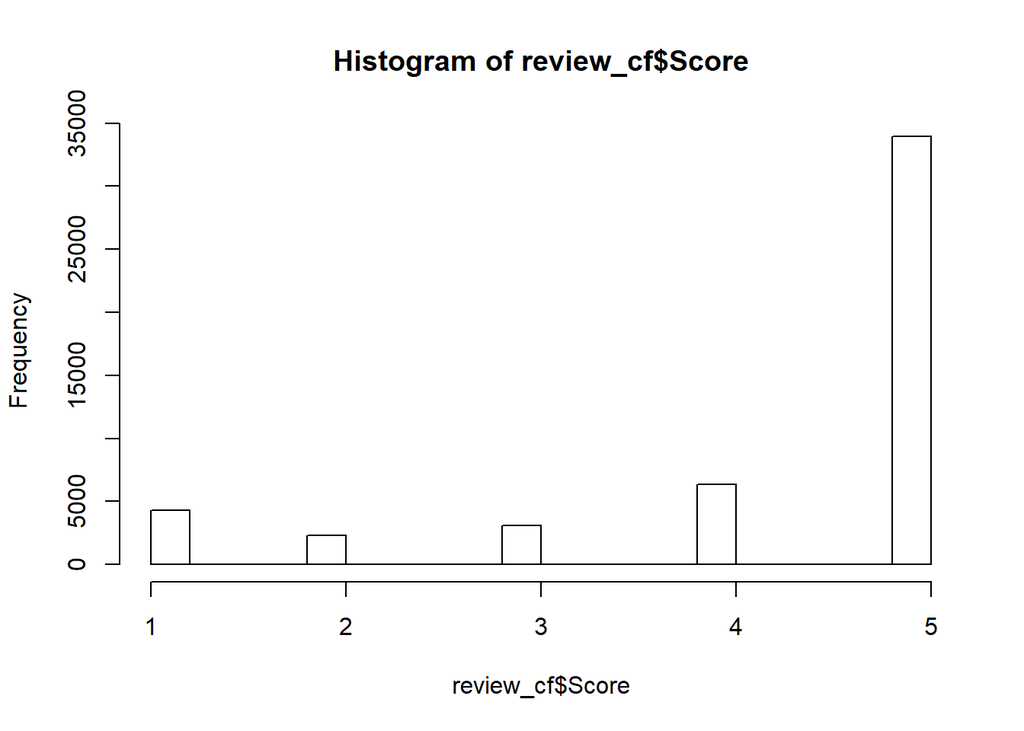

```r
hist(review_cf$Score)
```

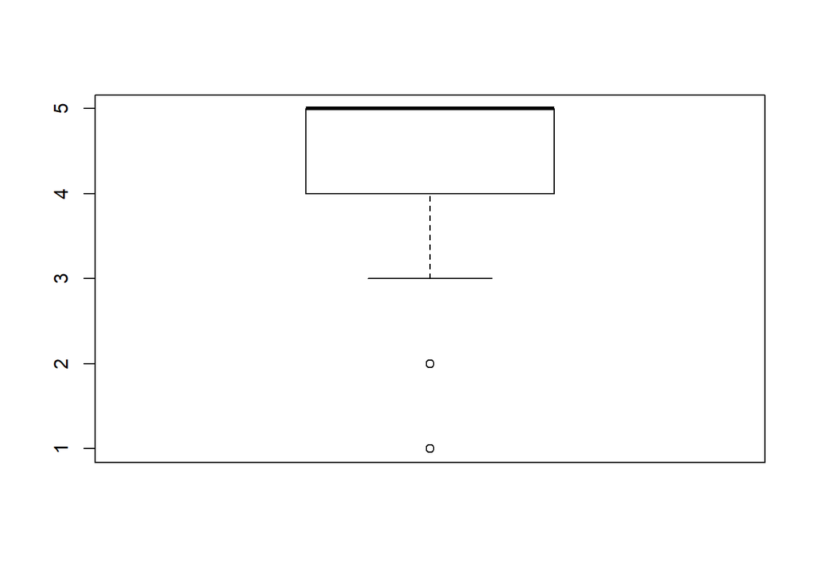

```r
boxplot(review_cf$Score)
```

Quick Look at the data for CF model

```r
kable(head(review_cf), format = "html")
```

| UserId | ProductId | Score |
| --- | --- | --- |
| AMX0PJKV4PPNJ | 0006641040 | 4 |
| AYZ0PR5QZROD1 | 0006641040 | 5 |
| A2QXYSXGQ2PKAU | 0006641040 | 3 |
| A3KKR87BJ0C595 | 0006641040 | 5 |
| A1HKYQOFC8ZZCH | 0006641040 | 1 |
| A3SJWISOCP31TR | 0006641040 | 5 |

```
## [1] "Number of user: 43349"
```

```
## [1] "Number of product: 1266"
```

As the number of user exceeds number of product, Item Based Collaborative Filtering (IBCF) is adopted. Another reason is due to the similarity among products tend to change at much slower pace as compared to the similarity among users

## IBCF - using recommenderlab package

Format the data to appropriate format to create sparse matrix

```r
# Create sparse matrix
review_spmatrix <- sparseMatrix(i = as.integer(review_cf$UserId),
                               j = as.integer(review_cf$ProductId),
                               x = as.numeric(review_cf$Score),
                               dimnames = list(unique(review_cf$UserId),
                                               unique(review_cf$ProductId))
                                )
```

```r
dim(review_spmatrix)
```

```
## [1] 43349  1266
```

```r
review_spmatrix[1:10,1:5]
```

[output not shown]

Sparse matrix has much smaller size

```r
print(object.size(review_spmatrix), units = 'auto')
```

```
## 3.6 Mb
```

In order to use recommenderlab, we need to convert sparse matrix to realRatingMatrix

```r
#format sparse matrix for recommenderlab library
review_sprrm <- as(review_spmatrix, 'realRatingMatrix')

review_sprrm
```

```
## 43349 x 1266 rating matrix of class 'realRatingMatrix' with 50000 ratings.
```

```r
dim(review_sprrm)
```

```
## [1] 43349  1266
```

```r
print(object.size(review_sprrm), units = 'auto')
```

```
## 3.6 Mb
```

#image(review_sprrm, main = “Raw Ratings”)

Split the data into training and testing subsets on 80/20

```r
given <- 1 #refer to https://stackoverflow.com/questions/30128383/error-evaluationscheme-recommenderlab-in-r
# some of the UserId only has 1 review so the given value cannot be more than 1
rating_threshold <- 4 # set 4 and above considered positive
eval <- evaluationScheme(review_sprrm, method = 'split', train = 0.8, given = given, goodRating = rating_threshold)
```

We will run a few variations of IBCF and also try Popular model to compare the result

1. IBCF with cosine similarity and not normalized data

```r
#IBCF with cosine similarity and not normalized data for k most similar items
IBCF_N_C <- Recommender(data = getData(eval, 'train'),
                        method = "IBCF",
                        parameter = list(normalize = NULL,
                                         method = 'Cosine', k = 30))
```

2. IBCF with cosine similarity and centered data

```r
# IBCF with cosine similarity and centered data for k most similar items
IBCF_C_C <- Recommender(data = getData(eval, 'train'),
                        method = 'IBCF',
                        parameter = list(normalize = "center", method = "Cosine", k = 30))
```

3. IBCF with cosine similarity and z-score normalized data

```r
# IBCF with cosine similarity and z-score normalised data for k most similar item
IBCF_Z_C <- Recommender(data = getData(eval, 'train'),
                       method = 'IBCF',
                       parameter = list(normalize = "Z-score", method = 'Cosine', k = 30))
```

4. Popular Model with centered data

```r
# Popular Model
POP <- Recommender(data = getData(eval, 'train'), method = 'POPULAR', param = list(normalize = 'center'))
```

We then evaluate the model against test data

```r
# Evaluation of IBCF
pIBCF_N_C <- predict(IBCF_N_C, getData(eval, 'known'), type = 'ratings')
pIBCF_C_C <- predict(IBCF_C_C, getData(eval, 'known'), type = 'ratings')
pIBCF_Z_C <- predict(IBCF_Z_C, getData(eval, 'known'), type = 'ratings')
pPOP <- predict(POP, getData(eval, 'known'), type = 'ratings')
```

```r
# Performance statistics
perf_stats <- rbind(
    IBCF_N_C = calcPredictionAccuracy(pIBCF_N_C, getData(eval, 'unknown')),
    IBCF_C_C = calcPredictionAccuracy(pIBCF_C_C, getData(eval, 'unknown')),
    IBCF_Z_C = calcPredictionAccuracy(pIBCF_Z_C, getData(eval, 'unknown')),
    pPOP = calcPredictionAccuracy(pPOP, getData(eval, 'unknown'))
    )

perf_stats
```

```
##              RMSE      MSE      MAE
## IBCF_N_C 3.918041 15.35105 2.098831
## IBCF_C_C 3.547819 12.58702 2.094675
## IBCF_Z_C 3.532676 12.47980 2.066132
## pPOP     4.607162 21.22594 2.803472
```

```r
#rm(IBCF_N_C, IBCF_C_C, IBCF_Z_C)
```

```r
IBCF_N_C
```

```
## Recommender of type 'IBCF' for 'realRatingMatrix'
## learned using 34679 users.
```

Test IBCF_N_C on unknown data

```r
pred<-predict(IBCF_N_C, getData(eval,'unknown'), n= 5)

as(pred, "list")[1:5]
```

```
## $AYZ0PR5QZROD1
## [1] "B0009F3SDM" "B000BXUVYG" "B000CQBZOC" "B000E63LQU" "B000E671Z2"
##
## $A1HKYQOFC8ZZCH
## character(0)
##
## $A3E7R866M94L0C
## character(0)
##
## $AJ46FKXOVC7NR
## [1] "B0000DID5R" "B0000DJDJZ" "B00016LA7K" "B00016LA8Y" "B0002L3BYE"
##
## $A2ONB6ZA292PA
## [1] "B000EDDSES" "B000GFYRM6" "B000GG0BNE" "B000GG1O6C" "B000I1RHMU"
```

We use the model to try recommend product to 1 existing user whose data is in the matrix

```r
# try to recommend item to 1 specific user
review_cf[review_final_small$UserId %in% c('AYZ0PR5QZROD1'),]
```

```
##          UserId  ProductId Score
## 2 AYZ0PR5QZROD1 0006641040     5
```

```r
rec_item <- predict(IBCF_N_C, review_sprrm["AYZ0PR5QZROD1",], n= 5 )

# display the recommendation
as(rec_item, "list")
```

```
## $AYZ0PR5QZROD1
## [1] "B0009F3SDM" "B000BXUVYG" "B000CQBZOC" "B000E63LQU" "B000E671Z2"
```

Get the ratings of the recommended items

```r
getRatings(rec_item)
```

```
## $AYZ0PR5QZROD1
## [1] 5 5 5 5 5
```

## Matrix Factorisation Approach

### ALTERNATING LEAST SQUARE on RECOSYSTEM

```r
# Train test split for Recosystem ALS
smp_size <- floor(0.9 * nrow(review_cf))
train_indexes <- sample(1: nrow(review_cf), size = smp_size)
trainevents <- review_cf[train_indexes, ]; dim(trainevents)
```

```
## [1] 45000     3
```

```r
testevents  <- review_cf[-train_indexes, ]; dim(testevents)
```

```
## [1] 5000    3
```

```r
#testevents1  <- review_cf[-train_indexes, ]; dim(testevents)
#head(testevents1)
```

Create Train and Test set in recosystem format

```r
# load into recosystem format
trainset = data_memory(trainevents$UserId, trainevents$ProductId, trainevents$Score, index1= TRUE)
testset  = data_memory(testevents$UserId, testevents$ProductId, testevents$Score, index1= TRUE)
```

```r
# get optimised factorisation using r$tune
r = Reco()
opts = r$tune(trainset, opts=list(dim=c(20, 30, 40), lrate=c(0.1,0.2), costp_l1=0, costq_l1=0, niter=40))

#opts

opts$min
```

```
## $dim
## [1] 20
##
## $costp_l1
## [1] 0
##
## $costp_l2
## [1] 0.1
##
## $costq_l1
## [1] 0
##
## $costq_l2
## [1] 0.01
##
## $lrate
## [1] 0.1
##
## $loss_fun
## [1] 2.595759
```

The min result shows dimension of 20. There is a possibility that the minimum dim is below 20 but shown as 20 as our lowest dim parameter set in initial run is 20. We will run again to try dimension 5, 10 and 20

```r
opts = r$tune(trainset, opts=list(dim=c(5, 10, 20), lrate=c(0.1,0.2), costp_l1=0, costq_l1=0, niter=40))

#opts

opts$min
```

```
## $dim
## [1] 5
##
## $costp_l1
## [1] 0
##
## $costp_l2
## [1] 0.1
##
## $costq_l1
## [1] 0
##
## $costq_l2
## [1] 0.01
##
## $lrate
## [1] 0.1
##
## $loss_fun
## [1] 2.479291
```

This time, the minimum dimension is 5. Again because 5 is the lowest in our list of test dimension, we will run the tune command one more time with narrower dimensions to ascertain the minimum dimension

```r
opts = r$tune(trainset, opts=list(dim=c(1:5), lrate=c(0.1,0.2), costp_l1=0, costq_l1=0, niter=40))

#opts

opts$min
```

```
## $dim
## [1] 5
##
## $costp_l1
## [1] 0
##
## $costp_l2
## [1] 0.1
##
## $costq_l1
## [1] 0
##
## $costq_l2
## [1] 0.01
##
## $lrate
## [1] 0.1
##
## $loss_fun
## [1] 2.479165
```

Best opts obtained and we will proceed to train using the best opts

```r
r$train(trainset, opts = opts$min)
```

```
## iter      tr_rmse          obj
##    0       3.2138  4.7596e+005
##    1       1.3605  9.5459e+004
##    2       0.6540  3.1971e+004
##    3       0.4611  2.2445e+004
##    4       0.3991  2.0090e+004
##    5       0.3737  1.9225e+004
##    6       0.3602  1.8788e+004
##    7       0.3516  1.8521e+004
##    8       0.3448  1.8303e+004
##    9       0.3393  1.8140e+004
##   10       0.3344  1.7996e+004
##   11       0.3298  1.7862e+004
##   12       0.3256  1.7737e+004
##   13       0.3216  1.7627e+004
##   14       0.3176  1.7518e+004
##   15       0.3138  1.7415e+004
##   16       0.3101  1.7313e+004
##   17       0.3065  1.7215e+004
##   18       0.3030  1.7126e+004
##   19       0.2994  1.7033e+004
```

Get the predicted result

```r
# get predictions:  this multiplies the user vectors in testset, with the item vectors in Q
testevents$prediction <- r$predict(testset, out_memory())
head(testevents)
```

```
##            UserId  ProductId Score prediction
## 2   AYZ0PR5QZROD1 0006641040     5    4.26956
## 6  A3SJWISOCP31TR 0006641040     5    4.26956
## 16    AZGXZ2UUK6X 0006641040     5    4.26956
## 33 A2QID6VCFTY51R 0006641040     5    4.26956
## 37  A25ACLV5KPB4W 0006641040     4    4.26956
## 41  AXVQSCC43HE99 B00002N8SM     3    4.26956
```

We subset data from the main dataset as a test data for ALS model

```r
# New dataset not seen before purely for testing ALS model
review_cftest <- review_final[100001:100500,c(3,1,5)]

review_cftest$UserId <- as.factor(review_cftest$UserId)
review_cftest$ProductId <- as.factor(review_cftest$ProductId)
review_cftest$Score <- as.numeric(review_cftest$Score)

#head(review_cftest)

# convert the test data to recosystem format
review_cftestset  = data_memory(review_cftest$UserId, review_cftest$ProductId, review_cftest$Score, index1= TRUE)

review_cftest$prediction <- r$predict(review_cftestset, out_memory())

kable(head(review_cftest, 30), format = "html")
```

|  | UserId | ProductId | Score | prediction |
| --- | --- | --- | --- | --- |
| 100001 | A2QC9920F42ORM | B001EQ54IM | 5 | 5.2305207 |
| 100002 | A2YEV05XY5GJ9U | B001EQ54IM | 5 | 4.9683313 |
| 100003 | A2Q4UX9QHLX9K8 | B001EQ54IM | 5 | 4.8198838 |
| 100004 | A3AGBJ6FYKE6O4 | B001EQ54IM | 4 | 4.3659549 |
| 100005 | A5R738LU8LSUB | B001EQ54IM | 5 | 4.2695599 |
| 100006 | A1Y3OPYLRYJJF2 | B001EQ54IM | 5 | 5.5325217 |
| 100007 | A2EUBM7HTPCZJ5 | B001EQ54IM | 5 | 5.4132476 |
| 100008 | A1OPLCTF66A49X | B001EQ54IM | 3 | 4.2582531 |
| 100009 | A3EBHHCZO6V2A4 | B001EQ54IM | 4 | 4.8207521 |
| 100010 | A3EBHHCZO6V2A4 | B001EQ54M8 | 5 | 3.3262432 |
| 100011 | AD369TZIKXXF0 | B001EQ54M8 | 5 | 3.3187864 |
| 100012 | A2FNVH31LT3MGL | B001EQ54M8 | 5 | 0.8802739 |
| 100013 | AEL6CQNQXONBX | B001EQ54M8 | 5 | 3.4559772 |
| 100014 | A30O1KHSE4A24E | B001EQ54M8 | 5 | 3.2515705 |
| 100015 | AQ65PTOT3SUH5 | B001EQ54M8 | 5 | 3.3855865 |
| 100016 | A29IPF6KF8D5YW | B001EQ54M8 | 1 | 2.5076017 |
| 100017 | AWVSCPEG6CHXG | B001EQ54M8 | 5 | 3.2634425 |
| 100018 | A3M330JARMFYTI | B001EQ54M8 | 5 | 2.9827266 |
| 100019 | ALUS3H9A378JI | B001EQ54M8 | 5 | 3.3348043 |
| 100020 | A2BARFPH0SFE6P | B001EQ54M8 | 4 | 3.7052393 |
| 100021 | A2A9UO8RND955S | B001EQ54M8 | 5 | 3.6721337 |
| 100022 | A1USLMR4BJ1RH0 | B001EQ54M8 | 5 | 4.2695599 |
| 100023 | A1VYJUUE1MEG46 | B001EQ54M8 | 5 | 3.0337439 |
| 100024 | A2MQAHM7U0H643 | B001EQ54M8 | 3 | 1.8515307 |
| 100025 | ARB94UKTX6OVK | B001EQ54M8 | 1 | 3.4106617 |
| 100026 | A2S6RZBC13UD7O | B001EQ54M8 | 5 | 3.5472798 |
| 100027 | AMWP1S4JBQRG7 | B001EQ54M8 | 4 | 2.7946343 |
| 100028 | AJJRE9K743P0V | B001EQ54M8 | 4 | 2.2471285 |
| 100029 | A18N5K4YXW5IDR | B001EQ54M8 | 5 | 2.8540485 |
| 100030 | A2CND8HXI5RW01 | B001EQ54M8 | 5 | 2.9986079 |

So far the test is done by inputing data in same format of actual train data, consisting of UserId, ProductId. For the recommender system to function, we will need it to take input of a few product the customer likes or have purchased and generate a list of recommended products. We have obtained the user latent feature matrix and product latent feature matrix which we can use to predict products to be recommended.

## Matrix Factorisation Manual Calculation Approach to recommend products to user given the product info provided by user

```r
#get factorised matrices
r$output() # exports the two matrix to the current directory (as mat_P.txt, mat_Q.txt)
```

```
## P matrix generated at mat_P.txt
## Q matrix generated at mat_Q.txt
```

```r
P = as.matrix(read.table("mat_P.txt")) # user
Q = as.matrix(read.table("mat_Q.txt")) # product
```

We assign UserId and ProductId as index to the matrices

```r
rownames(P) = as.factor(unique(review_cf$UserId))
rownames(Q) = as.factor(unique(review_cf$ProductId))
head(P) # the user factors matrix, rows = user, columns are the latent features
```

```
##                      V1       V2       V3       V4       V5
## AMX0PJKV4PPNJ  0.755018 0.505734 0.508077 0.662434 0.486587
## AYZ0PR5QZROD1  0.713581 0.465981 0.601743 0.385920 0.863905
## A2QXYSXGQ2PKAU 0.195130 0.286747 0.372885 0.242114 0.327175
## A3KKR87BJ0C595 0.601137 0.585820 0.678171 0.562114 0.889648
## A1HKYQOFC8ZZCH 0.478896 0.629130 0.661210 0.698762 0.565724
## A3SJWISOCP31TR 0.732933 0.611169 0.491119 0.794324 0.536484
```

```r
head(Q) # the item factors matrix, rows = items, columns are the latent features
```

```
##                  V1      V2      V3      V4       V5
## 0006641040 1.325940 2.01081 1.76657 1.56481 1.598460
## B00002N8SM 0.625318 1.50782 1.36457 1.16841 0.959242
## B00004RAMS 1.076120 1.76335 2.00496 1.72174 1.002010
## B00004RAMX 1.558110 1.71827 1.09549 2.04636 0.980457
## B00004RAMY 1.471010 1.73369 2.03019 1.50481 1.412040
## B00004RBDU 1.330140 1.52714 1.70557 1.90190 1.510800
```

### Testing the ALS Recommender

```r
# Create a string containing 5 new products through randomly selecting 5 products from the ProductId list
cust_order <- sample(unique(review_cf$ProductId), size = 5)

#drop levels and convert to string
cust_order <- levels(droplevels(cust_order))

cust_order
```

```
## [1] "B0000VJ55U" "B000EVT04C" "B000FUYCJ0" "B000HQRKYQ" "B000KJRF40"
```

The following codes take in the imaginary cust_order and for each of the item, it does a matrix multiplication to find top 5 users based on rating. Thereafter, for each of the 5 users, find top 5 products with highest rating to be returned as product to be recommended to customer placing the imaginary cust_order

```r
# empty matrix container for the final result
result = matrix(nrow = 0, ncol = 2)

#for each item in the cust_order, do a matrix multiplication to find top 5 user based on rating
for (item in cust_order){
    T = as.matrix(Q[item,])
    prats = P %*% T
    prats= prats[order(prats, decreasing = TRUE),]
    similar_user = names(prats)[1:5]
    #print(similar_user)

    # for each user, do a matrix multiplication back to find relevant products
    for (name in similar_user){
        # empty temporary matrix
        mat = ''
        T2 = as.matrix(P[name,])
        prats2 = Q %*% T2
        prats2 = prats2[order(prats2, decreasing = TRUE),]
        similar_product = prats2[1:5]
        mat <- cbind(as.vector(names(similar_product)), as.vector(similar_product))
        #print(mat)
        #retutn a matrix
        result <- rbind(result, mat)
    }

}
```

We then format the result, group them by ProductId to obtain average Rating as the rating for each product differ from one UserId to another UserId.

```r
#name the matrix
colnames(result) <- c('ProductId', 'Rating')

#dim(result)

# convert to dataframe
result_df <- as.data.frame(result[order(result[,2], result[,1], decreasing = TRUE),])

# convert Rating from factor to numeric, extra step in between, convert to char before numeric
result_df$Rating <- as.numeric(as.character(result_df$Rating))

#head(result_df,10)

# groupby and get the mean rating for each product, sort descending
cf_recom_product <- result_df %>%
    group_by(ProductId) %>%
    summarize(meanRating = mean(Rating)) %>%
    arrange(-meanRating) %>%
    mutate(Rank = order(meanRating, decreasing = TRUE))

# top 5 relevant products
cf_recom_product
```

```
## # A tibble: 11 x 3
##    ProductId  meanRating  Rank
##    <fct>           <dbl> <int>
##  1 B000FDDESC       8.76     1
##  2 B000FBM3YK       8.57     2
##  3 B000EDGBDI       8.56     3
##  4 B000FK8VHE       8.49     4
##  5 B000F7A5X0       8.38     5
##  6 B000EDDSES       8.32     6
##  7 B000FK7PQW       8.24     7
##  8 B000IKDIME       8.23     8
##  9 B000ED9L9E       8.09     9
## 10 B000GZU7QQ       7.99    10
## 11 B000FMTJJQ       7.88    11
```

## Content Based Recommender

Our second approach is to make use of the review text to obtain cosine similarity among products. With the similarity score, we then will be able to recommend items closest to the test items presented.

```r
# data for content based recommender
review_cb <- review_final_small
```

We combine all the review text and summary for each product.

```r
#collapse the summary to each ProductId
review_cb_prod2 <- aggregate(combine_summary ~ ProductId, data = review_cb_prod, FUN = paste, collapse = " ")

dim(review_cb_prod2)
```

```
## [1] 1266    2
```

1266 Products

```r
#check for duplication
nrow(review_cb_prod2[duplicated(review_cb_prod2$combine_summary),])
```

[output not shown]

```r
# check lengths
length(unique(review_cb_prod2$combine_summary))
length(unique(review_cb_prod2$ProductId))
```

[output not shown]

We proceed with processing the text to clean up unwanted text and convert them into Document Term Matrix

```r
# Remove non ASCII Character
review_cb_prod2$combine_summary <- iconv(review_cb_prod2$combine_summary, "UTF-8", "ASCII",sub='')

mystopwords = c(stopwords('english'), 'the', 'and', 'will', 'product')

desc_corpus <- VCorpus(VectorSource(review_cb_prod2$combine_summary))
desc_corpus <- tm_map(desc_corpus, content_transformer(tolower))
desc_corpus <- tm_map(desc_corpus, removeNumbers)
desc_corpus <- tm_map(desc_corpus, removeWords, mystopwords)
desc_corpus <- tm_map(desc_corpus, removePunctuation)
desc_corpus <- tm_map(desc_corpus, stemDocument)
desc_corpus <- tm_map(desc_corpus, removeWords, mystopwords)
desc_corpus <- tm_map(desc_corpus, stripWhitespace)
```

```r
for(i in 1:3){
    print(desc_corpus[[i]][1])
}
```

[output not shown]

Create TFIDF DTM

```r
#creating the Document Term Matrix
dtm <- DocumentTermMatrix(desc_corpus)
dtm_ti <- weightTfIdf(dtm)
dtm_ti
```

```
## <<DocumentTermMatrix (documents: 1266, terms: 43011)>>
## Non-/sparse entries: 693998/53757928
## Sparsity           : 99%
## Maximal term length: 93
## Weighting          : term frequency - inverse document frequency (normalized) (tf-idf)
```

The DTM is quite sparse. We try to reduce the sparsity

```r
dtm_ti2 = removeSparseTerms(dtm_ti, 0.99)

dtm_ti2
```

```
## <<DocumentTermMatrix (documents: 1266, terms: 5050)>>
## Non-/sparse entries: 617118/5776182
## Sparsity           : 90%
## Maximal term length: 14
## Weighting          : term frequency - inverse document frequency (normalized) (tf-idf)
```

Some of the words in the DTM

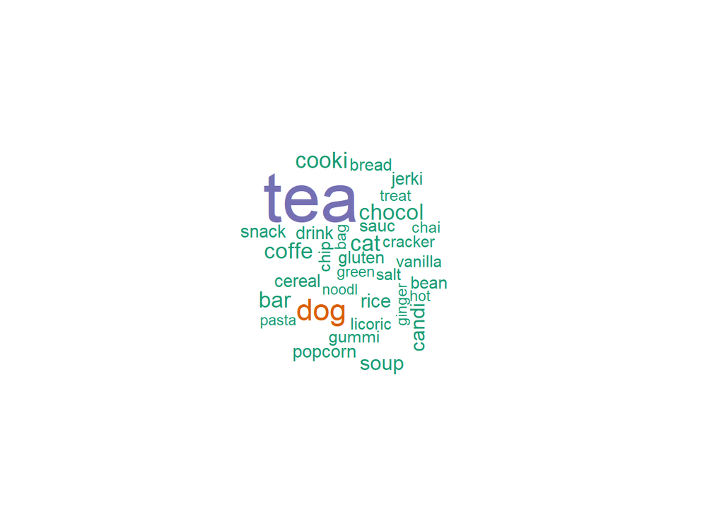

[output not shown]

```r
freq = data.frame(sort(colSums(as.matrix(dtm_ti2)), decreasing=TRUE))
wordcloud(rownames(freq), freq[,1], max.words=50, colors=brewer.pal(1, "Dark2"))
```

After the DTM is in order, we will use slam package to compute cosine similarity among products

```r
## Compute cosine similarity
# slam package for cosine similarity computation
sim_mat_cos <- crossprod_simple_triplet_matrix(t(dtm_ti2))/(sqrt(col_sums(t(dtm_ti2)^2) %*% t(col_sums(t(dtm_ti2)^2))))
```

Check if the dimension of sim_mat_cos is the same as number of unique product

```r
length(unique(review_cb_prod2$ProductId)) == dim(sim_mat_cos)[1]
```

```
## [1] TRUE
```

Assign colnames and rownames to the sim_mat_cos for indexing purpose

```r
rownames(sim_mat_cos) <- unique(review_cb_prod2$ProductId)
colnames(sim_mat_cos) <- unique(review_cb_prod2$ProductId)
#sim_mat_cos[1:5,1:30]
```

```r
## Function to return a prediction matrix, cannot get output out, need some working ###
#recProd = function (simm, prod, k) {
#    recom = matrix(ncol =2, nrow = 0)
#    for (i in cust_order){
#        output = ''
#        result <- sort(simm[, i], decreasing = TRUE)[2:(k+1)]
#        output <- cbind(as.vector(names(result)), as.vector((result)))
#        recom <- rbind(recom, output)
#        }
#    #print(recom)
#    return(recom)
#    }

#sort(sim_mat_cos[, 'B00004RBDZ'], decreasing = TRUE)[2:(5+1)]
```

For each of product input, the code below will generate k number of product to be recommended and combined into a dataframe

```r
k = 5 # number of product to be recommended
simm = sim_mat_cos
#create empty matrix to hold the output
recom = matrix(ncol =2, nrow = 0)
for (i in cust_order){
    output = ''
    result <- sort(simm[, i], decreasing = TRUE)[2:(k+1)]
    output <- cbind(as.vector(names(result)), as.vector((result)))
    recom <- rbind(recom, output)
    }

colnames(recom) <- c('ProductId', 'Rating')

cb_recom <- as.data.frame(recom[order(recom[,2], recom[,1], decreasing = TRUE),])

# convert Rating from factor to numeric, extra step in between, convert to char before numeric
cb_recom$Rating <- as.numeric(as.character(cb_recom$Rating))

kable(head(cb_recom,10), format = "html")
```

| ProductId | Rating |
| --- | --- |
| B000EVQWKW | 0.8106233 |
| B000EVT05G | 0.7102992 |
| B0002LDAHC | 0.7079011 |
| B000BWR26W | 0.7052542 |
| B000EVQWK2 | 0.6675893 |
| B000EVT042 | 0.6600095 |
| B000EVQWJ8 | 0.6592671 |
| B000G1X45G | 0.6522170 |
| B0000V8IOE | 0.6247484 |
| B000FL52IY | 0.6242424 |

We combine multiple rating for same product and take the average rating before sorting them descending

```r
# groupby and get the mean rating of each product, sort descending
cb_recom_product <- cb_recom %>%
    group_by(ProductId) %>%
    summarize(meanRating = mean(Rating)) %>%
    arrange(-meanRating) %>%
    mutate(Rank = order(meanRating, decreasing = TRUE))
```

```r
# all relevant products in descending order
cb_recom_product
```

```
## # A tibble: 25 x 3
##    ProductId  meanRating  Rank
##    <fct>           <dbl> <int>
##  1 B000EVQWKW      0.811     1
##  2 B000EVT05G      0.710     2
##  3 B0002LDAHC      0.708     3
##  4 B000BWR26W      0.705     4
##  5 B000EVQWK2      0.668     5
##  6 B000EVT042      0.660     6
##  7 B000EVQWJ8      0.659     7
##  8 B000G1X45G      0.652     8
##  9 B0000V8IOE      0.625     9
## 10 B000FL52IY      0.624    10
## # ... with 15 more rows
```

```r
#### CODE NOT IN USE #####
#names(result)

#result_i <- names(result)
#head(result_i)

# create tags for the product
#m1 <- as.matrix(dtm_ti2); dim(m1) # 679 rows, 6392 columns


# Obtain top 5 key words for each product
#tag <- t(apply(m1, 1, FUN = function(x) colnames(m1)[order(-x)[1:5]]))
#tag_unite <- unite(data.frame(tag), "tag", 1:5, sep = " ")

#saveRDS(sim_mat_cos, "./sim_mat_cos.rds")

#recProd = function (simm, prod, k) {
#    found <- sort(simm[, prod], decreasing = TRUE)[2:(k+1)]
#    print(found)
#    cat(paste0("Selected product : <title>", colnames(review_cb_prod2[prod,1])))
#    cat(paste0("Selected product: <title> ", review_cb_prod2[prod, 1]))
#    cat("\nRecommended products:\n")
#    resindex <- names(found)
#    print(resindex)
#    for (i in 1:k) {
#        cat(paste0("\n",i,"-", resindex[i], " <ProductId> ",
#                   review_cb_prod2[resindex[i], 1],
#                   "\n<tags> ",
#                   tag_unite[result_i[i],]))
#    }
#}
################################################################
```

```r
#review_final[review_final$ProductId == '0006641040',]
```

#### Hybrid Recommender

```r
#Check for intersect of the recommendations
common <- intersect(cf_recom_product$ProductId, cb_recom_product$ProductId)

common

cf_recom_product[cf_recom_product$ProductId == common,]

cb_recom_product[cb_recom_product$ProductId == common,]
```

[output not shown]

Normalize rating from ALS recommender as well as from Content Based Recommender

```r
#normalize cf_recom_product and cb_recom_product
cf_recom_product$meanRating = with(cf_recom_product, (meanRating - min(meanRating)) / (max(meanRating) - min(meanRating)))
cb_recom_product$meanRating = with(cb_recom_product, (meanRating - min(meanRating)) / (max(meanRating) - min(meanRating)))
#cf_recom_product
#cb_recom_product
```

Combine the normalized products from each recommender system

```r
combi_prod_recom <- rbind(cf_recom_product[,1:2], cb_recom_product[,1:2])

# Combined normalized products recommendation, sorted descending by meanRating
combi_prod_recom <- combi_prod_recom[order(combi_prod_recom$meanRating, decreasing = TRUE),]
#combi_prod_recom

# total number of items
nrow(combi_prod_recom)
```

```
## [1] 36
```

To ensure some surprise factor in the recommendation, we mixed the recommendation, taking 5 from top, 3 from middle and 2 from bottom.

```r
# recommend items from top 5, middle 3 and bottom 2 of the list to introduce a mix
combi_recom_mix <- combi_prod_recom[c(1:5,
                                      (nrow(combi_prod_recom)/2):(nrow(combi_prod_recom)/2+2),
                                      (nrow(combi_prod_recom)-1): nrow(combi_prod_recom)),
                                   ]
```

The sample customer order:

```r
cust_order
```

```
## [1] "B0000VJ55U" "B000EVT04C" "B000FUYCJ0" "B000HQRKYQ" "B000KJRF40"
```

The resulting recommendation:

```r
combi_recom_mix
```

```
## # A tibble: 10 x 2
##    ProductId  meanRating
##    <fct>           <dbl>
##  1 B000FDDESC      1
##  2 B000EVQWKW      1
##  3 B000EVT05G      0.843
##  4 B0002LDAHC      0.840
##  5 B000BWR26W      0.835
##  6 B0000CEPDP      0.619
##  7 B000FUMH4W      0.617
##  8 B000084F5E      0.590
##  9 B000FMTJJQ      0
## 10 B000EMAZS6      0
```